# Session 5

R Introduction Workshop

August 09, 2017

# `mpg` data

`ggplot2` dataset, you need to first load `tidyverse` or `ggplot2`

Fuel economy data from 1999 and 2008 for 38 popular models of car

```r
library(tidyverse)
?mpg
head(mpg,3)
```

```
## # A tibble: 3 × 11
##   manufacturer model displ  year   cyl      trans   drv   cty   hwy    fl
##          <chr> <chr> <dbl> <int> <int>      <chr> <chr> <int> <int> <chr>
## 1         audi    a4   1.8  1999     4   auto(l5)     f    18    29     p
## 2         audi    a4   1.8  1999     4 manual(m5)     f    21    29     p
## 3         audi    a4   2.0  2008     4 manual(m6)     f    20    31     p
## # ... with 1 more variables: class <chr>
```

```r
mpg$class[1:20]
```

```
##  [1] "compact" "compact" "compact" "compact" "compact" "compact" "compact"
##  [8] "compact" "compact" "compact" "compact" "compact" "compact" "compact"
## [15] "compact" "midsize" "midsize" "midsize" "suv"     "suv"
```

# Data Visualization with `ggplot`: Barplots

`geom_bar` is designed to make it easy to create bar charts that show **counts**

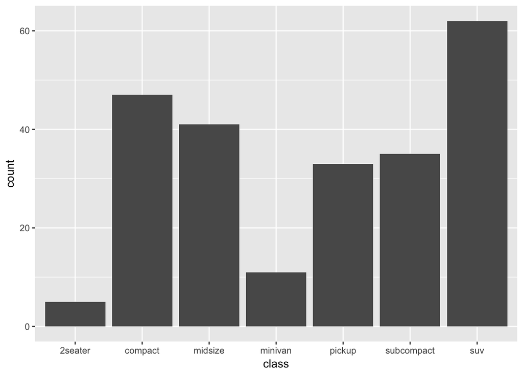

```r
g <- ggplot(mpg, aes(class))
# Number of cars in each class:
g + geom_bar()
```

## Stacked

Bar charts are automatically stacked when multiple bars are “defined”" at the same location.  
**description of `drv`:** f = front-wheel drive, r = rear wheel drive, 4 = 4wd

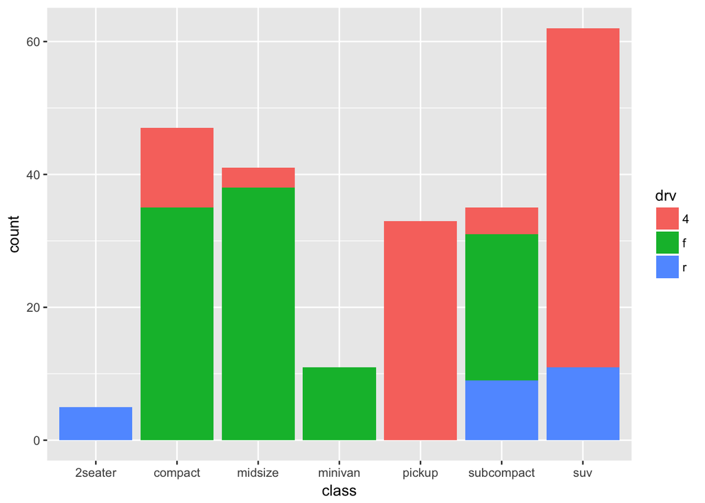

```r
g + geom_bar(aes(fill = drv))
```

## Side by side

To have side by side plots for the groups you would like to compare, you need to use the `position` argument within the `geom_` functions. You can either simply assign the name of positioning as a string or assign a `position_` function for more details.

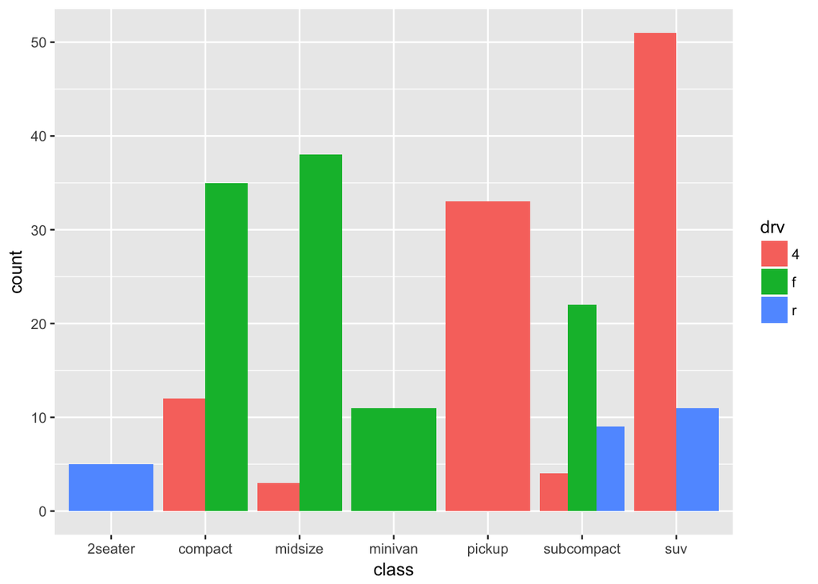

```r
g + geom_bar(aes(fill = drv), position = "dodge")
```

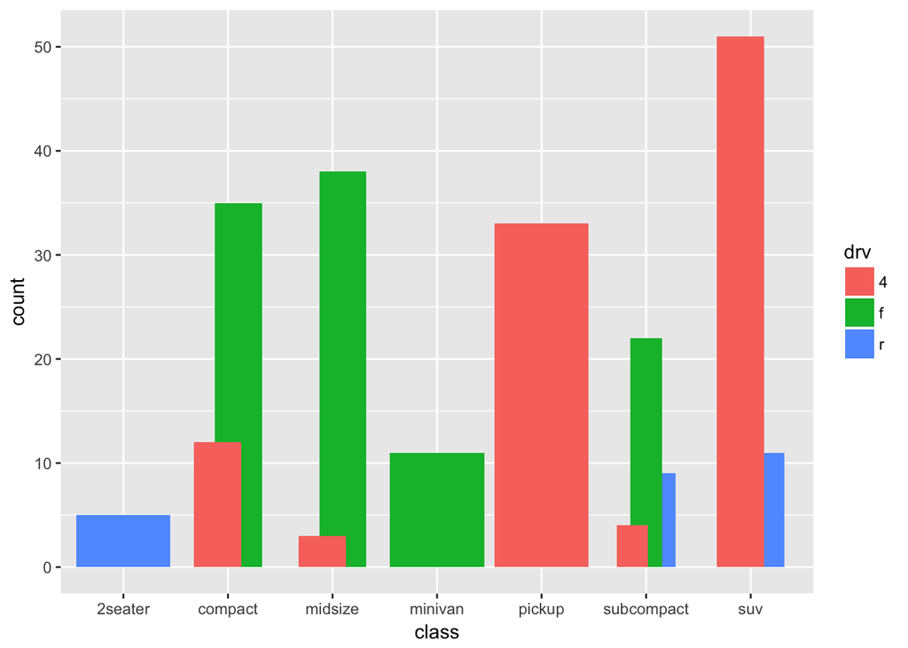

```r
g + geom_bar(aes(fill = drv),position = position_dodge(width = 0.4))
```

## Visualizing data points or mean as barplot

Unfortunately `ggplot2` will not calculate means of a variable for you.  
If you would like to plot means or any other values other than the count of categories you need to provide them to `ggplot()` in the following format:

Assuming that outcome is the mean outcome of treatments (`trt`) `a`, `b` and `c` here.

```r
df <- data.frame(trt = c("a", "b", "c"), outcome = c(2.3, 1.9, 3.2))
df
```

```
##   trt outcome
## 1   a     2.3
## 2   b     1.9
## 3   c     3.2
```

Then use `geom_col()`

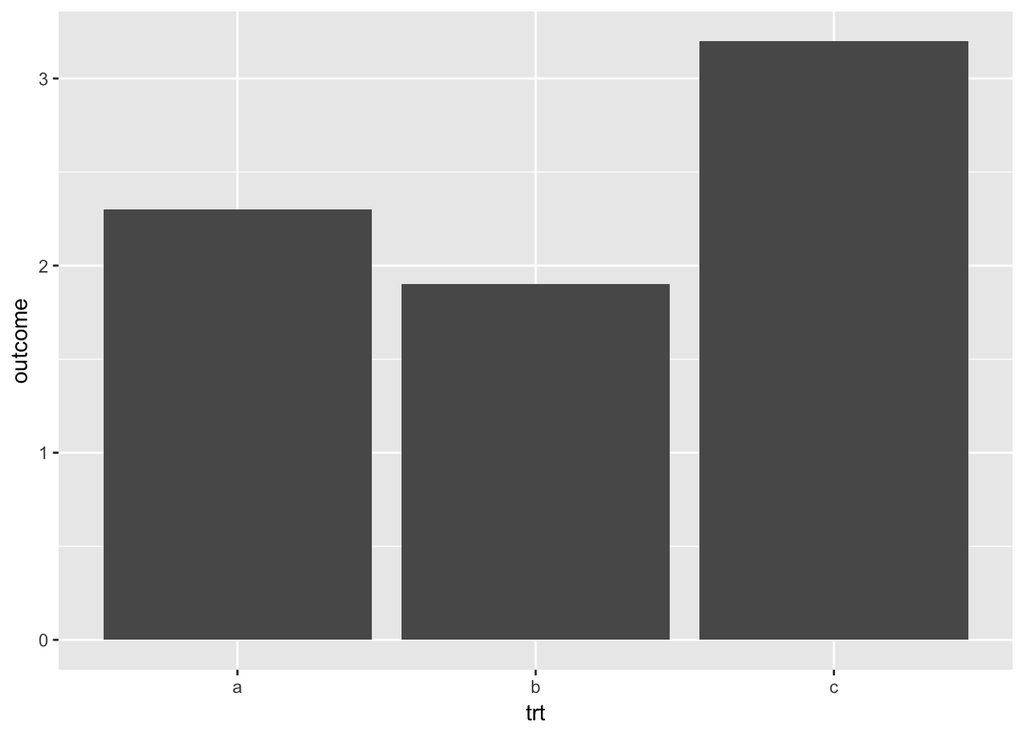

```r
ggplot(df, aes(trt, outcome)) +
  geom_col()
```

You can also change colors easily

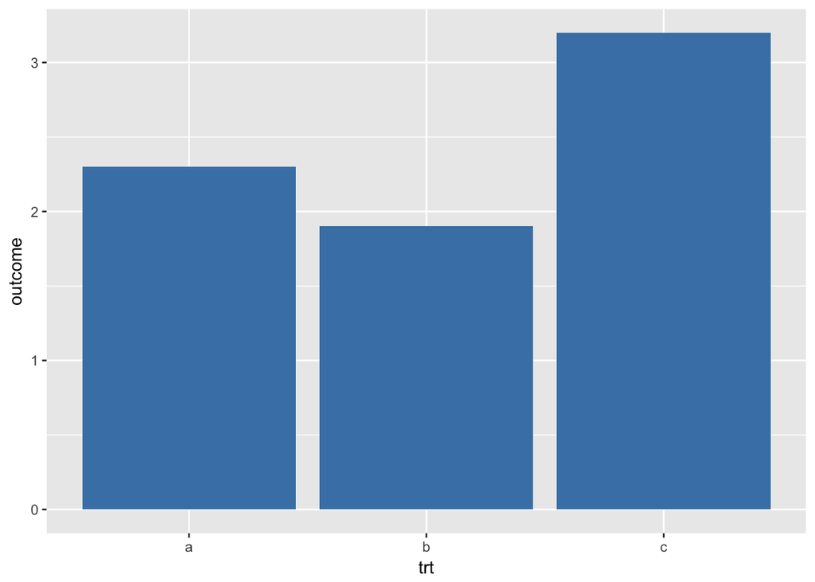

```r
ggplot(df, aes(trt, outcome)) +
  geom_col(fill="steelblue")
```

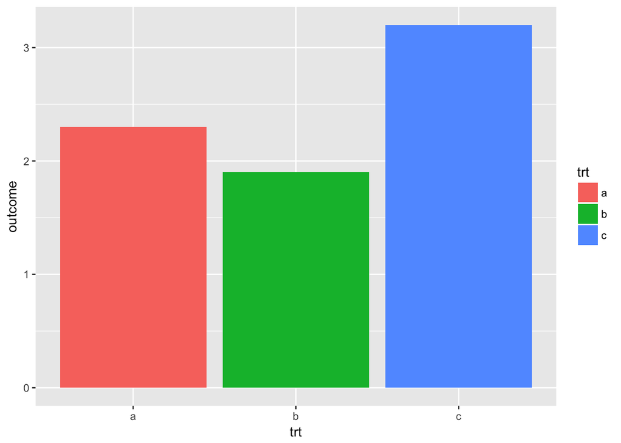

```r
ggplot(df, aes(trt, outcome)) +
  geom_col(aes(fill=trt))
```

## `geom_bar()` with continuous data

You can also use geom_bar() with continuous data, in which case it will show counts at unique locations.

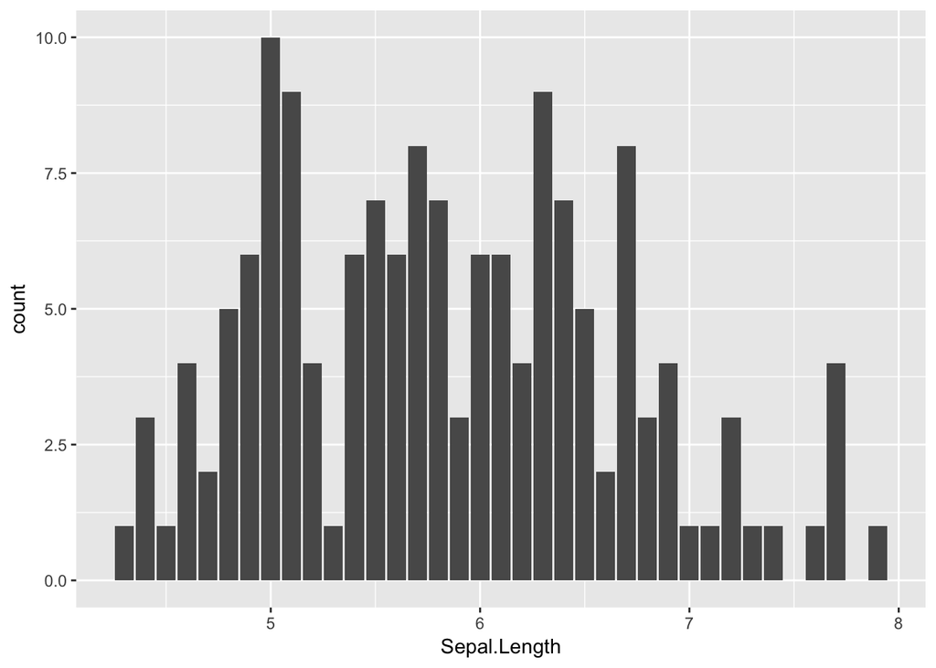

```r
ggplot(iris, aes(Sepal.Length)) + geom_bar()
```

# Data Visualization with `ggplot`: Histograms

Histograms are basically barplots with “bins”.  
To construct a histogram,

> 1. “bin” the range of values. What is meant by “bining” is, to divide the entire range of values into a series of intervals.
> 2. Then count how many values fall into each interval.

The bins are usually specified as consecutive, non-overlapping intervals of a variable.

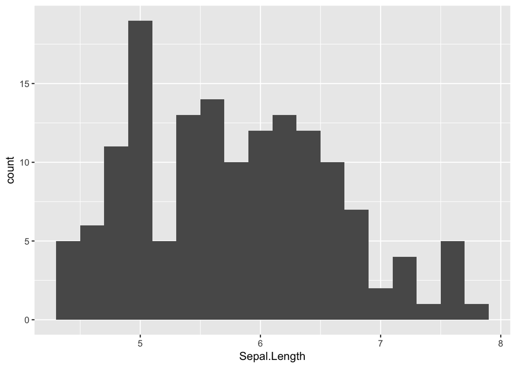

```r
ggplot(iris, aes(Sepal.Length)) + geom_histogram(binwidth = 0.2)
```

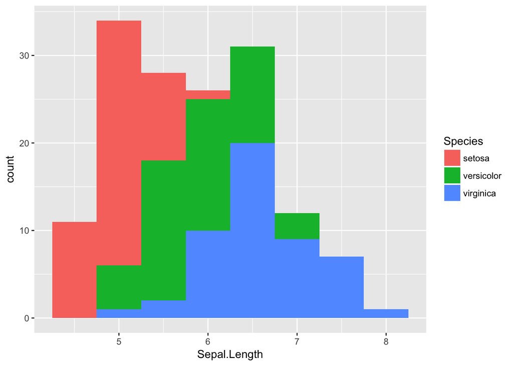

```r
ggplot(iris, aes(Sepal.Length, fill=Species)) +
  geom_histogram(binwidth = 0.5)
```

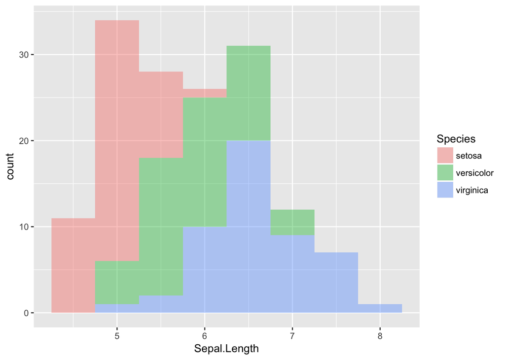

```r
ggplot(iris, aes(Sepal.Length, fill=Species)) +
  geom_histogram(binwidth = 0.5, alpha=0.4)
```

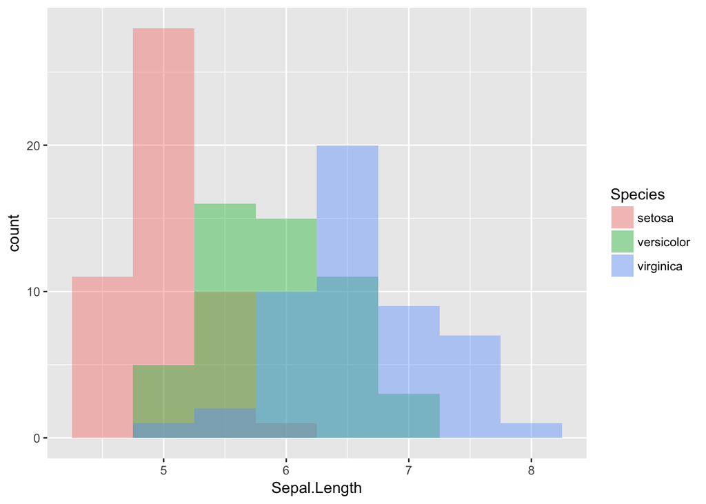

```r
ggplot(iris, aes(Sepal.Length, fill=Species)) +
  geom_histogram(binwidth = 0.5, position = "identity", alpha=0.4)
```

# Data Visualization with `ggplot`: Boxplots

A box plot is a easy way to get some overall idea about the distribution of your variable. Let’s have a quick review on how to read a box plot:

[figure not shown]

Boxplot (with an interquartile range) and a probability density function (pdf) of a Normal N(0,σ2) Population

# Example `ToothGrowth` dataset

```r
head(ToothGrowth)
```

```
##    len supp dose
## 1  4.2   VC  0.5
## 2 11.5   VC  0.5
## 3  7.3   VC  0.5
## 4  5.8   VC  0.5
## 5  6.4   VC  0.5
## 6 10.0   VC  0.5
```

```r
?ToothGrowth
```

Here’s how the the distribution of tooth length for different regimens look like.

```r
gb <- ToothGrowth %>%
      unite(regimen, -len, sep= "_") %>%
      ggplot(data=., aes(regimen, len)) +
      geom_boxplot(aes(color=regimen))
```

Are you confused with this code?  
We could get the exact same result with the following:

```r
ToothGrowth$regimen <- paste(ToothGrowth$supp, ToothGrowth$dose, sep="_")

gb <- ggplot(data=ToothGrowth, aes(regimen, len)) +
      geom_boxplot(aes(color=regimen))
gb
```

[output not shown]

So you see, these `dplyr` functions just make life a little easier, and potentially your code looks cleaner and easier to read. We’ll talk about that later.

# Bonus: `geom_dotplot`

What’s a dotplot?

In a dot plot, the width of a dot corresponds to the bin width (or maximum width, depending on the binning algorithm), and dots are stacked, with each dot representing one observation.

Example:

```r
set.seed(2211) # get the same random variables from the normal distribution
df <- data.frame(x= paste0("time",sort(rep(1:4, 25))),
                 y= c(rnorm(25, 0, 2),
                      rnorm(25, 1, 2),
                      rnorm(25, 2, 2),
                      rnorm(25, 3, 2)))
head(df)
```

```
##       x          y
## 1 time1  0.4339022
## 2 time1 -1.7532299
## 3 time1  3.1492460
## 4 time1  0.5317880
## 5 time1  2.2812159
## 6 time1  0.6126187
```

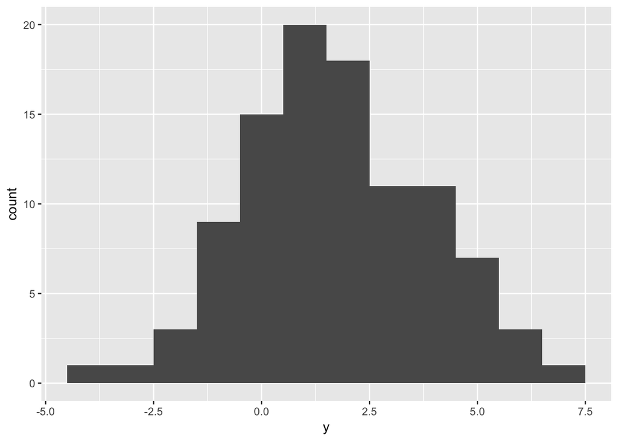

```r
# look at distribution of y
ggplot(data=df, aes(y)) + geom_histogram(binwidth = 1)
```

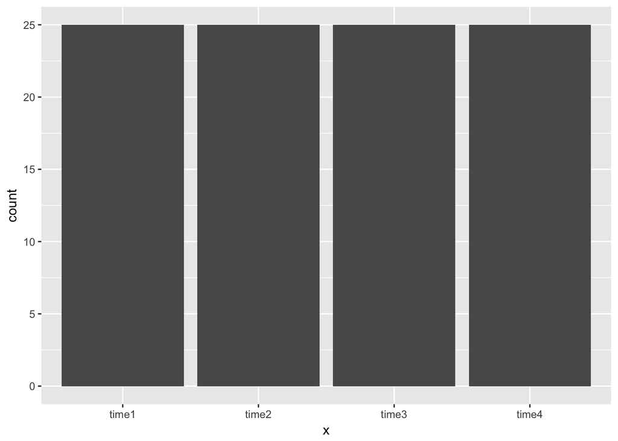

```r
# look at distribution of x
ggplot(data=df, aes(x)) + geom_bar()
```

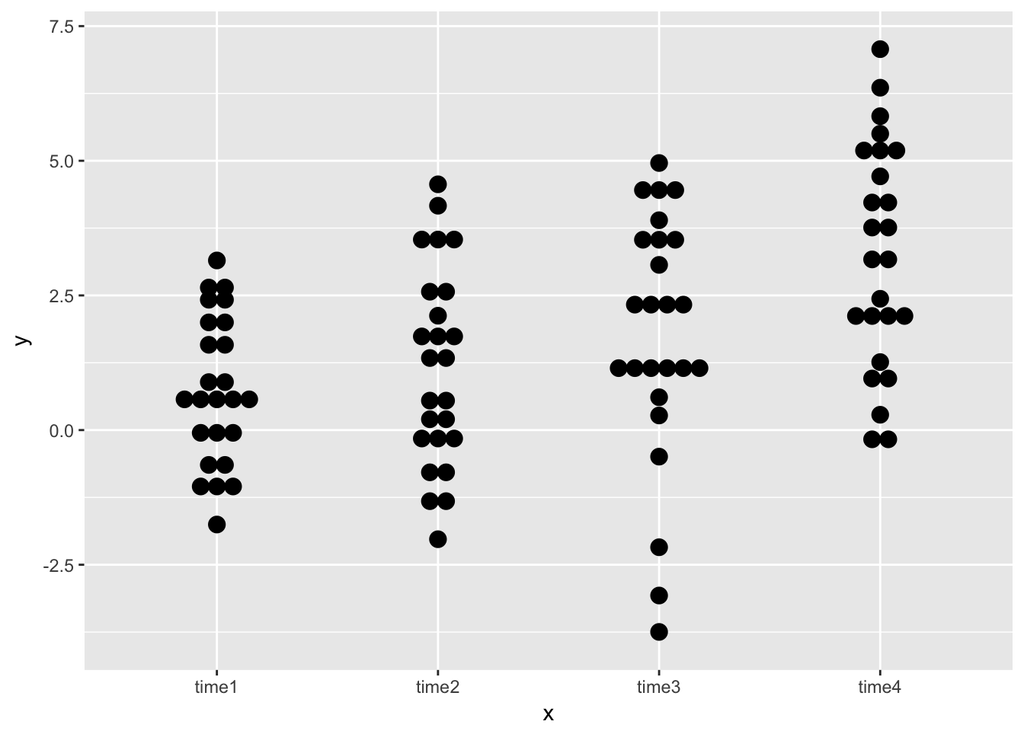

```r
# now lets look with dotplot
ggplot(data=df, aes(x, y)) +
  geom_dotplot(binaxis="y",
               binwidth = 0.3,
               stackdir = "center")
```

## Your turn

Change the `binwidth` to `0.1`, `0.5`, `1` one by one. Then change the `stackdir` to “up” (default), “down”, “center”, “centerwhole”.

What’s happening?

## Let’s go back to ToothGrowth data and apply `geom_dotplot`

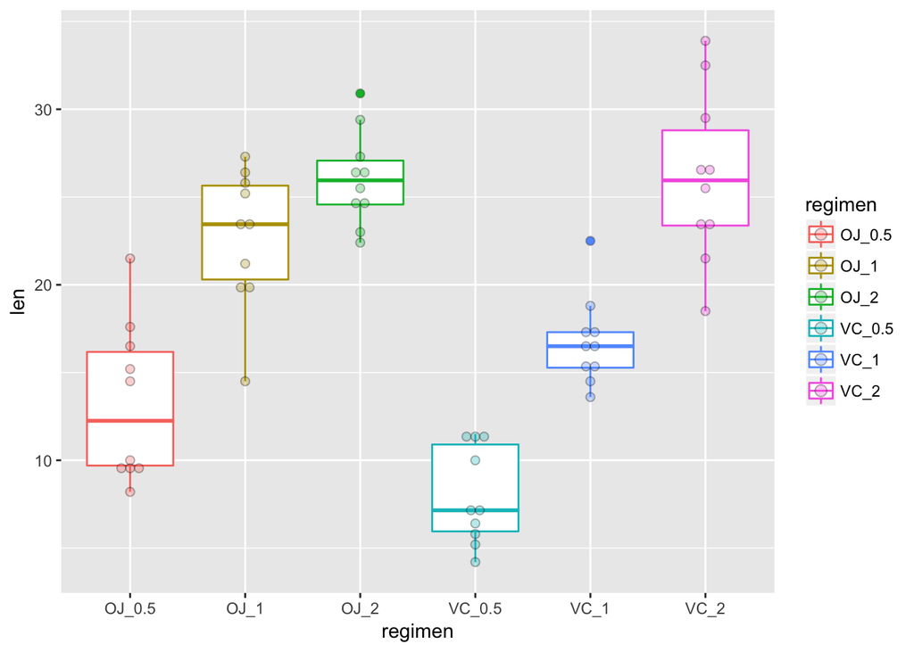

```r
gb + geom_dotplot(binwidth = 0.5,
                  aes(fill = regimen),
                  alpha = 0.3,
                  binaxis = "y",
                  stackdir = "center")
```

# `ggplot2`: Plotting means and error bars

The error bars can define multiple *types of variation*:

1. **Standard deviation (`sd`)** shows how much each data point deviate from the mean “on average”. This is useful if you would like to have a general idea about how the data is distributed.
2. **Standard error of the mean (`sem`)** gives a value explaining how much your estimated mean is affected by the sampling variability. It can be difficult to interpret.
3. **95% Confidence interval (`ci95`)** the interval which you are 95% certain that the true mean falls into. This is probably the best *type of variation* if we are really interested in estimating the mean.
- Go to this [cute article](http://blog.minitab.com/blog/statistics-and-quality-data-analysis/variations-on-a-theme-of-variation-r-v-sd-se-and-ci) for better a explanation.

As mentioned earlier, `ggplot2` requires calculated summary statistics to be given to the `ggplot()` in a data frame form. This is why I keep mentioning `dplyr` package. It provides nice tools to manipulate data and get some summary statistics out of it.

So, now I will to compute the `mean`, `sd`, `sem` and `CI95`. To compute `sem` and `CI95` I need to write my own functions…

# Writing custom functions in R

Now I would like to write my own custom functions to compute some of the statistics.  
For that I will use the `function()` function. For example, I would like to define a function called `add5mult3mean` that

> 1. Takes a numeric vector
> 2. Adds 5 to all of its elements
> 3. Multiplies with 3
> 4. And finally gives the mean of this modified vector

```r
add5mult3mean <- function(x) mean((x+5)*3)

myVec <- 1:10
add5mult3mean(myVec)
```

```
## [1] 31.5
```

```r
# or
mean((myVec+5)*3)
```

```
## [1] 31.5
```

You can name the argument whatever you want as long as it’s consistent throughout your function.  
So the following would again give me the same:

```r
add5mult3mean <- function(a_numeric_vector) mean((a_numeric_vector+5)*3)
add5mult3mean(myVec)
```

```
## [1] 31.5
```

You can add as many arguments as you want and use objects in your environment.

```r
irisChopper <- function(breaks){
  chopped.iris <- data.frame(cat.Sep.Len = cut(iris$Sepal.Length, breaks = breaks),
             cat.Sep.Wid = cut(iris$Sepal.Width, breaks = breaks),
             cat.Pet.Len = cut(iris$Petal.Length, breaks = breaks),
             cat.Pet.Wid = cut(iris$Petal.Width, breaks = breaks),
             iris$Species)
  head(chopped.iris)
}

irisChopper(10)
```

```
##   cat.Sep.Len cat.Sep.Wid  cat.Pet.Len   cat.Pet.Wid iris.Species
## 1 (5.02,5.38] (3.44,3.68] (0.994,1.59] (0.0976,0.34]       setosa
## 2 (4.66,5.02]  (2.96,3.2] (0.994,1.59] (0.0976,0.34]       setosa
## 3 (4.66,5.02]  (2.96,3.2] (0.994,1.59] (0.0976,0.34]       setosa
## 4  (4.3,4.66]  (2.96,3.2] (0.994,1.59] (0.0976,0.34]       setosa
## 5 (4.66,5.02] (3.44,3.68] (0.994,1.59] (0.0976,0.34]       setosa
## 6 (5.38,5.74] (3.68,3.92]  (1.59,2.18]   (0.34,0.58]       setosa
```

```r
irisChopper(0:10)
```

```
##   cat.Sep.Len cat.Sep.Wid cat.Pet.Len cat.Pet.Wid iris.Species
## 1       (5,6]       (3,4]       (1,2]       (0,1]       setosa
## 2       (4,5]       (2,3]       (1,2]       (0,1]       setosa
## 3       (4,5]       (3,4]       (1,2]       (0,1]       setosa
## 4       (4,5]       (3,4]       (1,2]       (0,1]       setosa
## 5       (4,5]       (3,4]       (1,2]       (0,1]       setosa
## 6       (5,6]       (3,4]       (1,2]       (0,1]       setosa
```

Now lets get back to our functions to calculate some statistics. Function `sem()` computes the standard error of the mean for a numeric vector. Similarly, `ci95` function computes the mean confidence interval of the numeric vector given.

```r
# here I am defining a function
# that would compute the standard error of the mean
sem <- function(x) sd(x)/sqrt(length(x))

# here I am defining a function
# that would compute the CI95.
# am computing this with t-distribution
# since I don't know the population standard deviation and
# my sample size for each treatment group is less than 30 --- a general rule
# qt() function is the t-distribution quantile function.
# It basically give the t-statistic value for the quantile given
ci95 <- function(x)  qt(0.975,df=length(x)-1)*sd(x)/sqrt(length(x))
```

If you run these commands, you’ll see that you have defined functions in your environment.

Now let’s apply these to our data using `dplyr` functions.

## Compute stats for `ToothGrowth`

```r
tg.stats <- ToothGrowth %>%
  group_by(supp, dose) %>% # group by
  summarise(.,
            mean.len = mean(len),  # mean
            sd.len = sd(len),      # sd
            se.len = sem(len),     # sem
            ci95.len = ci95(len),  # ci95
            n = length(len)) %>%   # count
 right_join(ToothGrowth)
```

Here I am using the pipe `%>%` and functions `group_by()`, `summarise()`, `right_join()` from the `dplyr` package. Let’s not get into details now, but very briefly this is what I am doing:

1. `ToothGrowth %>%` I am piping the `ToothGrowth` data in the function that comes up next. This way I can keep piping things to other functions.
   - `x %>% f(y)` is the same as `f(x, y)`
   - `y %>% f(x, ., z)` is the same as `f(x, y, z )`
2. `group_by(supp, dose)`: Grouping it based on its `supp` and `dose` columns.
3. `summarize(...)`: Computing the statistics for every `len` observation in the respective `supp` and `dose` group. Statistics I compute are:  
   -`sd`  
   -`sem`  
   -`ci95`  
   `length` (this isn’t really a statistic is just the count of the observation in each group)
4. right_join(ToothGrowth)I am appending the summary statistics to the original data

Now this is how `tg.stats` look

```r
tg.stats
```

```
## Source: local data frame [60 x 8]
## Groups: supp [?]
##
##      supp  dose mean.len   sd.len   se.len ci95.len     n   len
##    <fctr> <dbl>    <dbl>    <dbl>    <dbl>    <dbl> <int> <dbl>
## 1      VC   0.5     7.98 2.746634 0.868562 1.964824    10   4.2
## 2      VC   0.5     7.98 2.746634 0.868562 1.964824    10  11.5
## 3      VC   0.5     7.98 2.746634 0.868562 1.964824    10   7.3
## 4      VC   0.5     7.98 2.746634 0.868562 1.964824    10   5.8
## 5      VC   0.5     7.98 2.746634 0.868562 1.964824    10   6.4
## 6      VC   0.5     7.98 2.746634 0.868562 1.964824    10  10.0
## 7      VC   0.5     7.98 2.746634 0.868562 1.964824    10  11.2
## 8      VC   0.5     7.98 2.746634 0.868562 1.964824    10  11.2
## 9      VC   0.5     7.98 2.746634 0.868562 1.964824    10   5.2
## 10     VC   0.5     7.98 2.746634 0.868562 1.964824    10   7.0
## # ... with 50 more rows
```

Finally we can start plotting! Let’s start with line graphs.

## Point and Line graphs

Step by step:

### 1. Just plot mean tooth length as data points

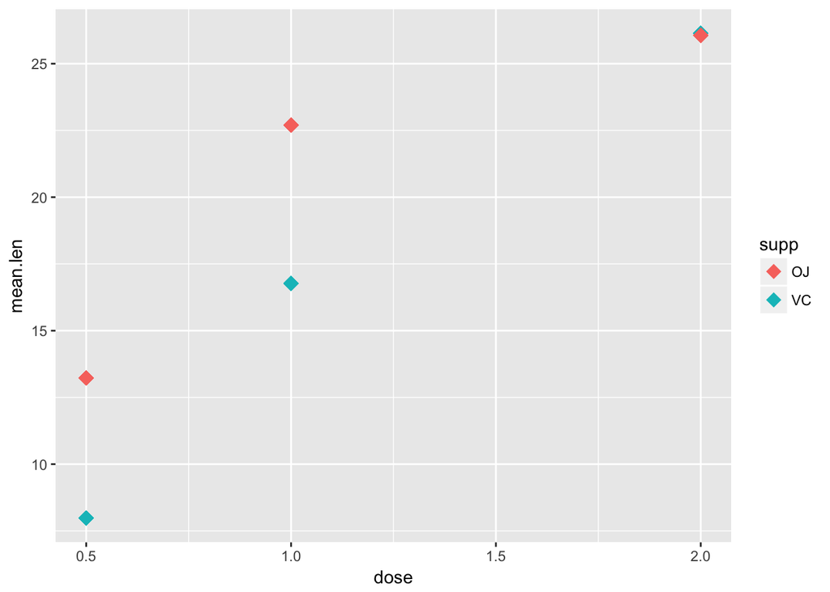

```r
ggplot(tg.stats, aes(x=dose, y=mean.len, colour=supp)) +
    geom_point(aes(x=dose, y= mean.len), size=4, shape=18)
```

Oh you’re wondering about the shapes? We’ll come to that…

### 2. Add the error bars: Show confidence intervals

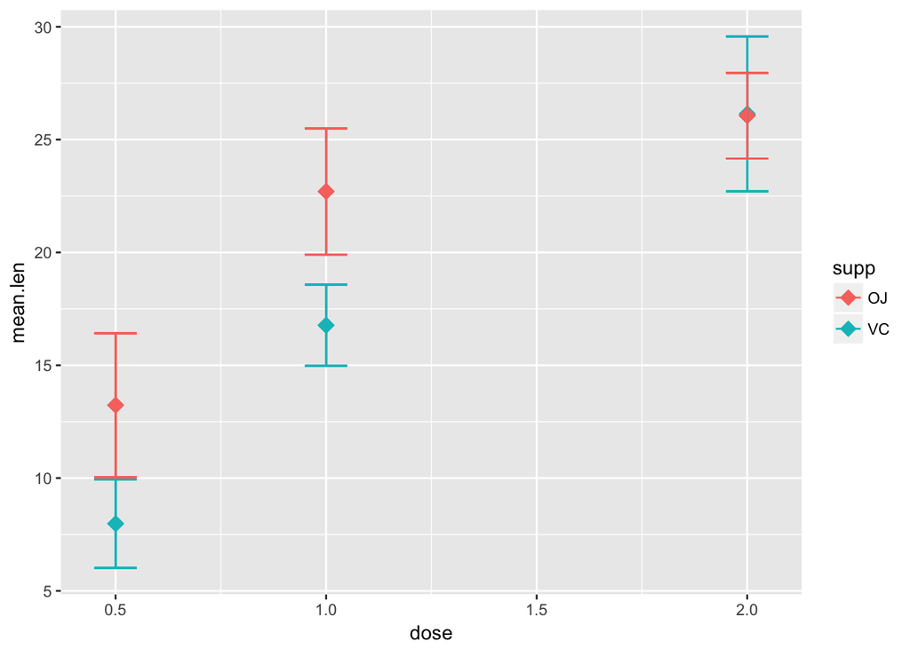

```r
ggplot(tg.stats, aes(x=dose, y=mean.len, colour=supp)) +
  geom_point(aes(x=dose, y= mean.len), size=4, shape=18) +
  geom_errorbar(aes(ymin=mean.len-ci95.len, ymax=mean.len+ci95.len), width=.1)
```

### 3. Add lines

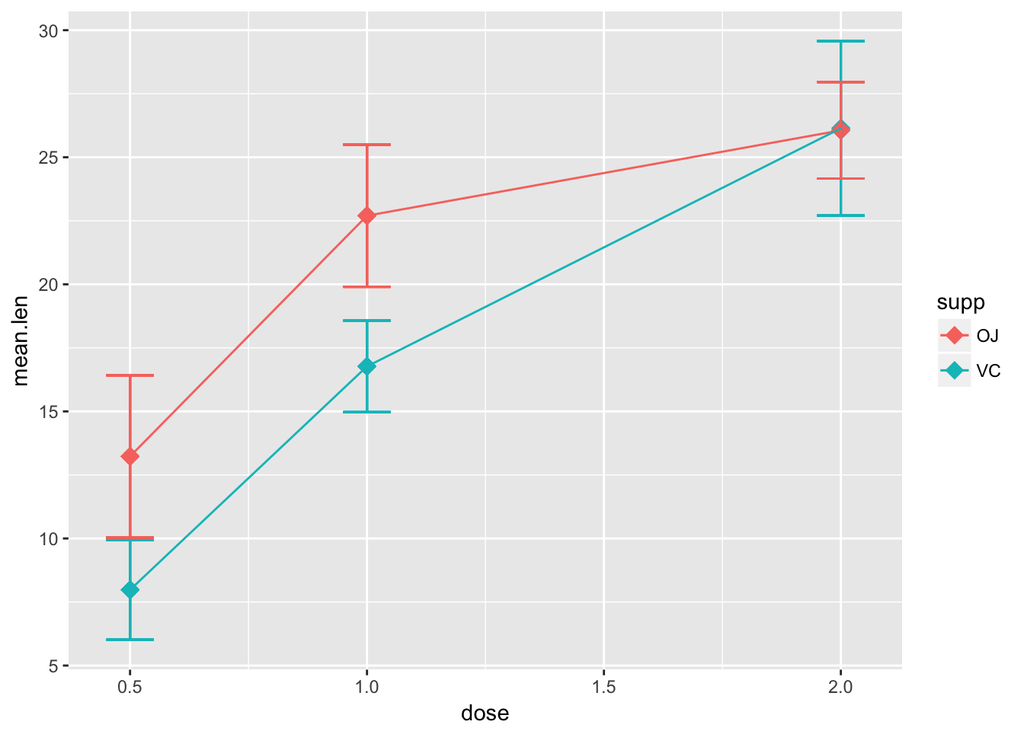

```r
ggplot(tg.stats, aes(x=dose, y=mean.len, colour=supp)) +
  geom_point(aes(x=dose, y= mean.len), size=4, shape=18) +
  geom_errorbar(aes(ymin=mean.len-ci95.len, ymax=mean.len+ci95.len), width=.1) +
  geom_line()
```

### 4. Add original data points

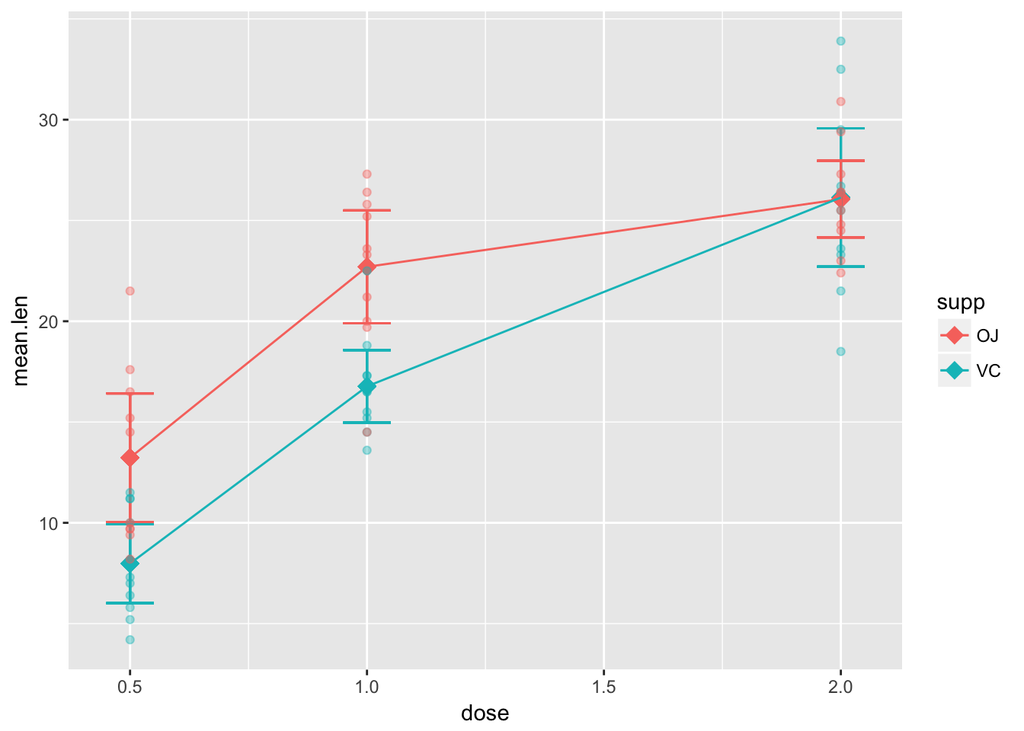

```r
ggplot(tg.stats, aes(x=dose, y=mean.len, colour=supp)) +
  geom_point(aes(x=dose, y= mean.len), size=4, shape=18) +
  geom_errorbar(aes(ymin=mean.len-ci95.len, ymax=mean.len+ci95.len), width=.1) +
  geom_line() +
  geom_point(aes(x=dose, y=len, fill=supp), alpha=0.4, size=1.5)
```

Now that we have more or less the plot we want, let’s customize it further.

# Customizing graphs with `ggplot2`

## 1. Change titles and set scale limits

Modify axis, legend, and plot labels see [Reference ggplot2: Scale](http://ggplot2.tidyverse.org/reference/index.html#section-scales)

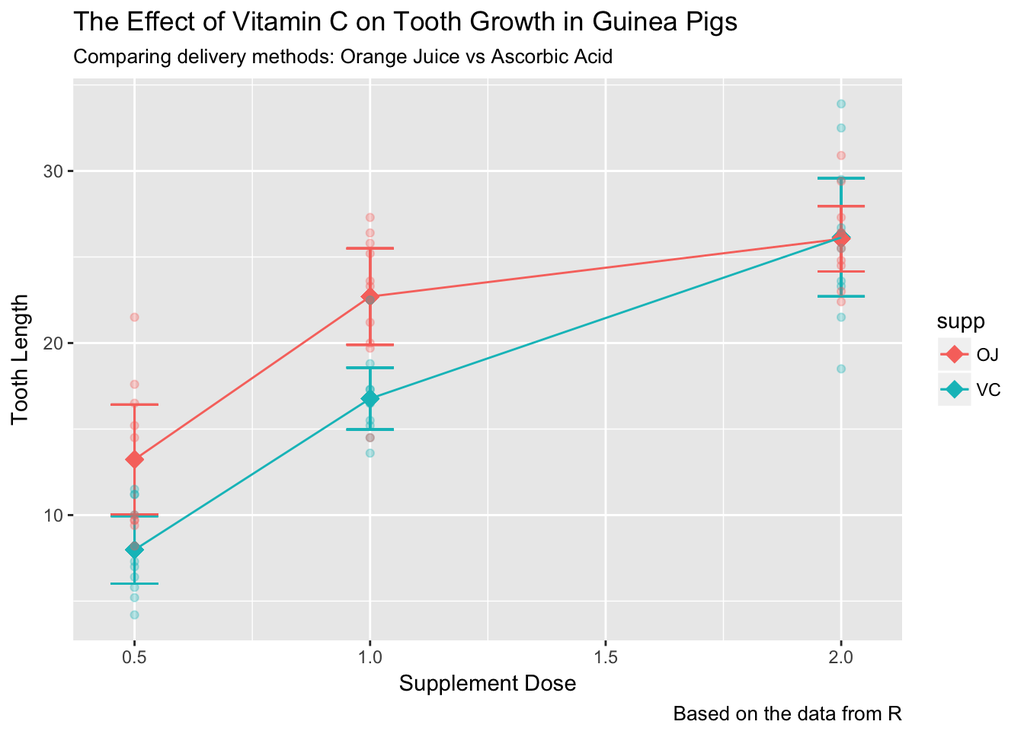

```r
ggplot(tg.stats, aes(x=dose, y=mean.len, colour=supp)) +
  geom_point(aes(x=dose, y= mean.len), size=4, shape=18) +
  geom_errorbar(aes(ymin=mean.len-ci95.len, ymax=mean.len+ci95.len), width=.1) +
  geom_line() +
  geom_point(aes(x=dose, y=len, fill=supp), alpha=0.3, size=1.5) +

# Here I add the titles I want
  labs(x="Supplement Dose",
       y="Tooth Length",
       title= "The Effect of Vitamin C on Tooth Growth in Guinea Pigs",
       subtitle= "Comparing delivery methods: Orange Juice vs Ascorbic Acid",
       caption = "Based on the data from R")
```

Define the limits of axes

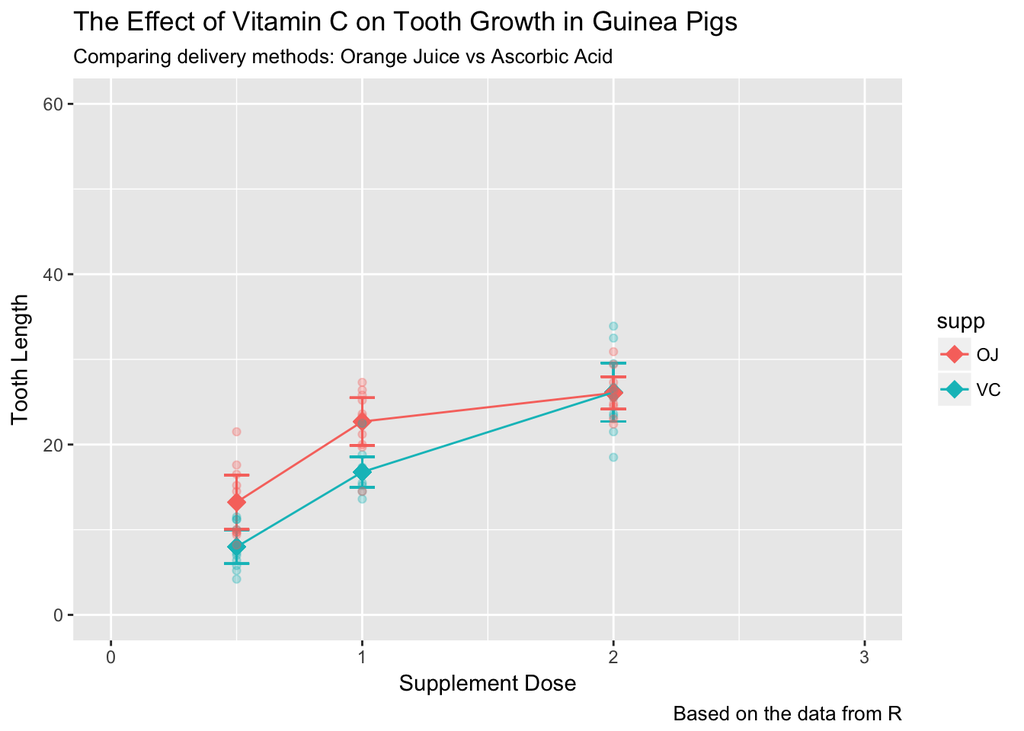

```r
ggplot(tg.stats, aes(x=dose, y=mean.len, colour=supp)) +
  geom_point(aes(x=dose, y= mean.len), size=4, shape=18) +
  geom_errorbar(aes(ymin=mean.len-ci95.len, ymax=mean.len+ci95.len), width=.1) +
  geom_line() +
  geom_point(aes(x=dose, y=len, fill=supp), alpha=0.3, size=1.5) +

# Here I add the titles I want
  labs(x="Supplement Dose",
       y="Tooth Length",
       title= "The Effect of Vitamin C on Tooth Growth in Guinea Pigs",
       subtitle= "Comparing delivery methods: Orange Juice vs Ascorbic Acid",
       caption = "Based on the data from R") +

# Change x and y axes limits
  xlim(0, 3) +
  ylim(0, 60)
```

## 2. Change legend title

We saw in the previous session how to change legend parameters with `guides()` function. To change the legend title we can use the same function. See (Reference ggplot2 Guides)[http://ggplot2.tidyverse.org/reference/index.html#section-guides-axes-and-legends]

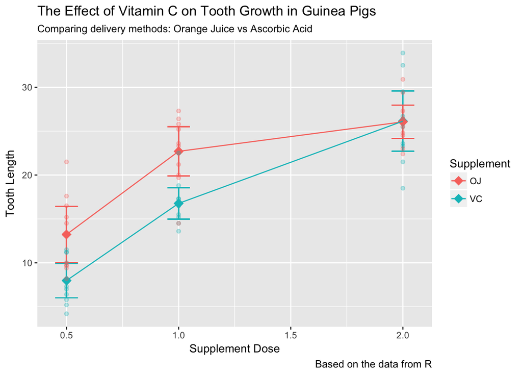

```r
ggplot(tg.stats, aes(x=dose, y=mean.len, colour=supp)) +
  geom_point(aes(x=dose, y= mean.len), size=4, shape=18) +
  geom_errorbar(aes(ymin=mean.len-ci95.len, ymax=mean.len+ci95.len), width=.1) +
  geom_line() +
  geom_point(aes(x=dose, y=len, fill=supp), alpha=0.3, size=1.5) +

# Here I add the titles I want
  labs(x="Supplement Dose",
       y="Tooth Length",
       title= "The Effect of Vitamin C on Tooth Growth in Guinea Pigs",
       subtitle= "Comparing delivery methods: Orange Juice vs Ascorbic Acid",
       caption = "Based on the data from R") +

# Change the legend
  guides(colour=guide_legend("Supplement"), fill=guide_legend("Supplement"))
```

## 3. Jitter points

I want to customize the `jitter` of the points. To adjust positions look at [position adjustment in ggplot2 Reference](http://ggplot2.tidyverse.org/reference/index.html#section-layer-position-adjustment)

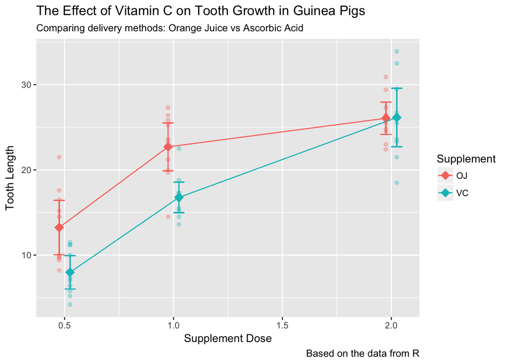

```r
pd <- position_dodge(0.1)

# my plot is getting very long, I'll assign it
tgp <- ggplot(tg.stats, aes(x=dose, y=mean.len, colour=supp)) +
  geom_point(aes(x=dose, y= mean.len), size=4, shape=18, position=pd) +
  geom_errorbar(aes(ymin=mean.len-ci95.len, ymax=mean.len+ci95.len), width=.1, position=pd) +
  geom_line(position=pd) +
  geom_point(aes(x=dose, y=len, fill=supp), alpha=0.3, size=1.5, position=pd) +


# Here I add the titles I want
  labs(x="Supplement Dose",
       y="Tooth Length",
       title= "The Effect of Vitamin C on Tooth Growth in Guinea Pigs",
       subtitle= "Comparing delivery methods: Orange Juice vs Ascorbic Acid",
       caption = "Based on the data from R") +

# Change the legend
  guides(colour=guide_legend("Supplement"), fill=guide_legend("Supplement"))

tgp
```

## 4. Themes

Theme allows to make `cosmetic` changes

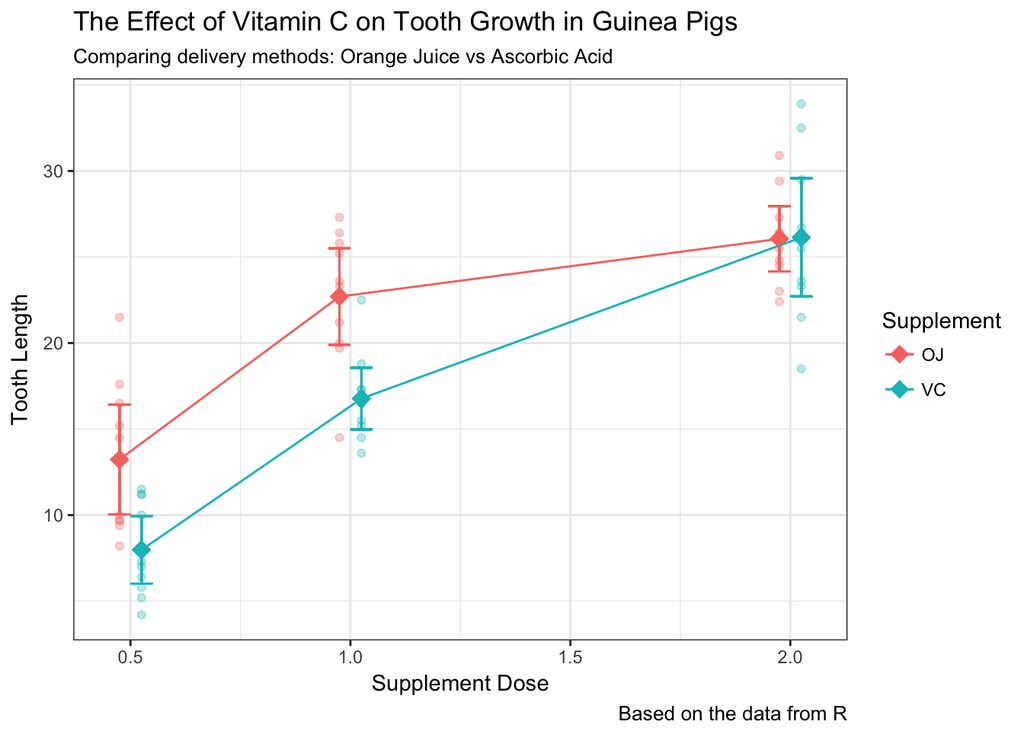

```r
tgp + theme_bw()
```

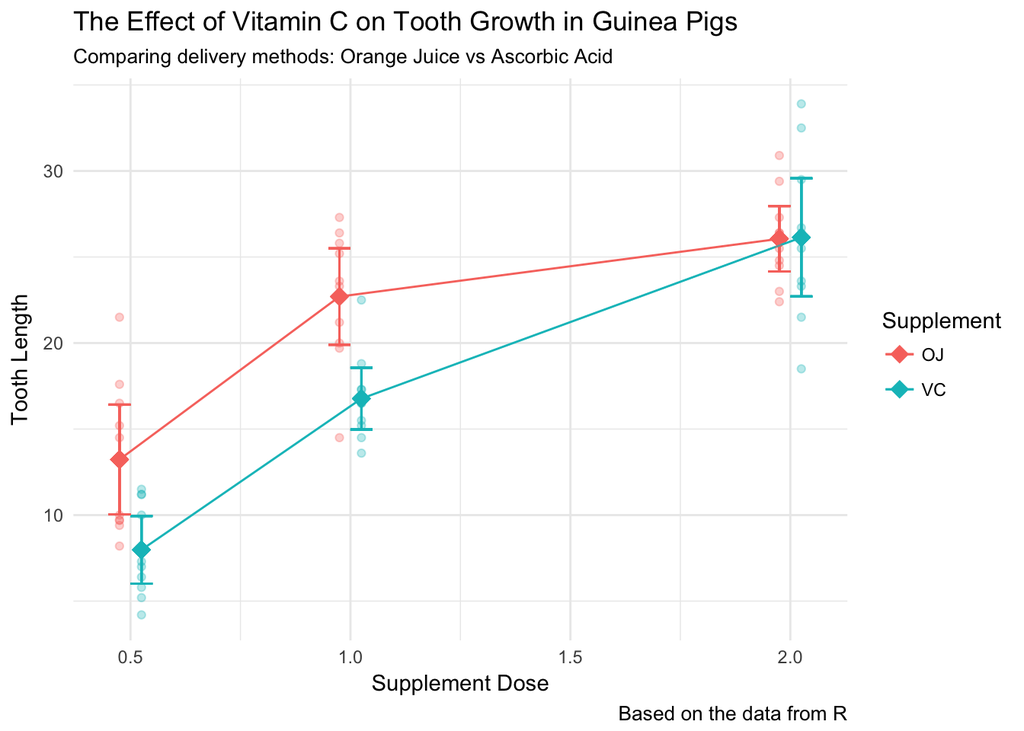

```r
tgp + theme_minimal()
```

## 5. Shapes

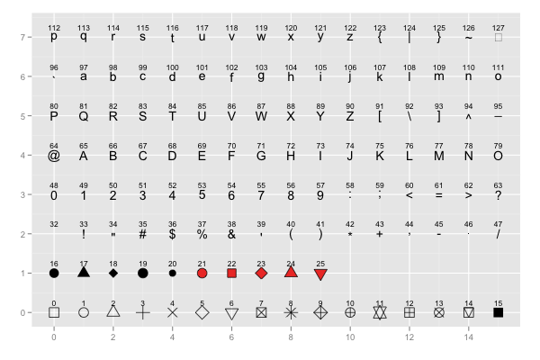